# Tema 1: Introducción a R y operadores lógicos

Carlos de la Calle carlos.callearroyo@uclm.es

4/2/2021

# Inicio

En esta primera sesión vamos a empezar con los conceptos básicos de R, desde su instalación a algunas particularidades del lenguaje y su sintaxis.

## ¿Qué es R?

R es un sistema para análisis estadísticos y gráficos creado por Ross Ihaka y Robert Gentleman. R tiene una naturaleza doble de programa y lenguaje de programación y es considerado como un dialecto del lenguaje S creado por los Laboratorios AT&T Bell.

R se distribuye gratuitamente bajo los términos de la *GNU General Public Licence*, y se trata de una herramienta flexible y práctica para multitud de problemas relacionados con el ámbito de la estadística y el análisis de datos.

Una de sus fortalezas radica en la facilidad tanto para crear código y compartirlo con la comunidad, como para obtener código creado por terceros para la resolución de problemas, que veremos más adelante en el apartado dedicado a paquetes.

## Instalación de R y RStudio

La instalación de R es un proceso sencillo. Como ya se ha mencionado anteriormente, R se puede usar de forma gratuita, y los instaladores para el mismo se pueden descargar de https://cran.r-project.org/. Hay versión para Windows, Macintosh y Linux, basta con bajarse el instalador correspondiente a la máquina en la que lo queramos instalar y ejecutarlo como cualquier otra rutina de instalación.

La interfaz por defecto de R es bastante sencilla, y puede intimidar un poco: consta tan solo de la consola, un editor, y una barra de herramientas bastante minimalista.

[figure not shown]

Apariencia R base

Durante el curso vamos a trabajar con un IDE, o entorno de desarrollo, llamado RStudio. Es uno de los más populares y es sencillo de utilizar.

Para su instalación se requiere tener instalado R previamente. RStudio lo detecta automáticamente durante la misma, por lo que basta descargarse el instalador de su página web https://www.rstudio.com/products/rstudio/download/. En nuestro caso escogeremos la licencia de escritorio gratuita.

## Primeras nociones del lenguaje

R es un lenguaje **Orientado a Objetos** e **interpretado**, de sintaxis sencilla.

**Orientado a Objetos** significa que las variables, datos, funciones, resultados, fórmulas, etc., se guardan en la memoria activa del computador en forma de objetos con un nombre especíıfico. El usuario puede modificar o manipular estos objetos con operadores (aritméticos, lógicos y comparativos) y funciones (que a su vez son objetos).

Que sea un lenguaje **interpretado** significa que los comandos escritos en el teclado son ejecutados directamente sin necesidad de construir ejecutables.

Iremos viendo cuestiones sobre la sintaxis de R a lo largo de todo el curso.

### R como calculadora

El primero y más sencillo de los usos de R es como calculadora. Se pueden introducir directamente en la consola operaciones aritméticas y R realiza los cálculos de forma directa, como se puede ver a continuación:

```r
3+6
```

```
## [1] 9
```

```r
9252/3
```

```
## [1] 3084
```

Como hemos mencionado antes, los resultados de R son objetos. Esto se puede ver en el número que aparece la izquierda, el `[1]` nos dice que se trata del primer elemento del objeto que contiene los resultados.

Hemos visto que al evaluar las expresiones anteriores se muestran los resultados en la consola (veremos más sobre ella más adelante). Esto se debe a que R llama a la función `print` de forma implícita (esto no es así en todos los lenguajes, ni siempre en R). Podemos ver que el resultado de evaluar print de las anteriores expresiones es, de hecho, el mismo.

```r
print(3+6)
```

```
## [1] 9
```

```r
print(9252/3)
```

```
## [1] 3084
```

Un concepto que puede resultar útil es el de obtener los resultados de la última evaluación. Si bien es recomendable que si queréis acceder a algún resultado generado almacenéis este en una variable, se puede acceder a la última evaluación a través de `.Last.value`, probad a ejecutar las siguientes instrucciones una después de otra en la consola:

```r
5+6
5*.Last.value
```

**EJERCICIO 1**

Para familiarizarnos un poco más con las instrucciones sencillas y el trabajo por consola, vamos a resolver la siguiente ecuación en la consola de R: $x^2+5x-3=0$ Se puede hacer en los pasos que se quiera.

*Notas*:

- La solución de una ecuación de segundo grado es: $X=\frac{-b\pm\sqrt{b^2-4ac}}{2a}$
- La función raíz cuadrada en R es sqrt()

### Limpiar la consola

A estas alturas seguro que tenéis un montón de código y resultados en la consola. Para despejar la consola, basta utilizar el atajo de teclado `ctrl+l`. Esto **no** hace desaparecer los cálculos, objetos o variables, simplemente elimina el texto de la consola para facilitar que futuros cálculos sean legibles.

Alternativamente, hacer click en el icono de la escoba consigue el mismo efecto:

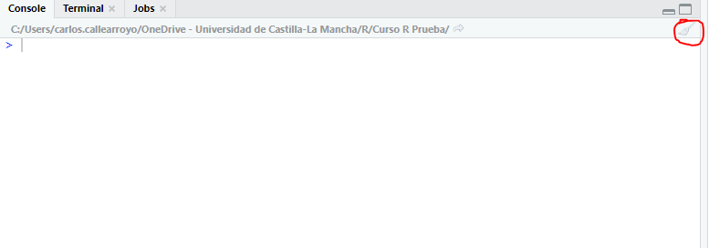

Limpiar Consola

## Variables y asignación: sintaxis

Si bien este uso de R puede ser conveniente en algunas ocasiones, lo realmente interesante son aquellos apartados relativos a programación, trabajo con variables, resolución de problemas complejos y visualización, entre otros.

Como hemos dicho antes, R es un lenguaje orientado a objetos. Los objetos que crea el usuario se pueden almacenar en variables, para lo cuál debemos “asignar” estas variables. La asignación en R se puede realizar con tres operadores: `<-`, `->` y `=`.

Para asignaciones de “nivel alto”, las tres son equivalentes:

```r
n1 <- 5
3 -> n2
n3 = 7
print(paste(n1, n2, n3))
```

```
## [1] "5 3 7"
```

Los operadores `<-` y `->` son equivalentes entre sí, realizan la misma función y de hecho, al modificar uno se modifica el otro. Típicamente es el primero el utilizado, y más sencillo de leer.

Entre estos dos y `=` la diferencia la explica John Chambers:

> The operator <- can be used anywhere, whereas the operator = is allowed in only two places in the grammar: at the top level (as a complete program or user-typed expression); and when isolated from surrounding logical structure, by braces or an extra pair of parentheses.

Eso quiere decir, por un lado, que dondequiera que se use el operador `<-` se produce una asignación. Esto tiene particular relevancia en funciones con operadores con nombre:

```r
x <- rnorm(100)
y <- 2*x+rnorm(100)
z <- 3*x+rnorm(100)
data1 <- data.frame(z,x,y)
rm(x,y,z)
```

Y a la hora de llamar a la función, podemos encontrarnos diferentes casos según los operadores que escojamos (no os preocupéis por la salida de la función en sí):

```r
lm(formula=z~x+y,data=data1)
lm(data=data1,formula=z~x+y)
lm(formula <- z~x+y, data <- data1)
lm(data <- data1, formula <- z~x+y)
```

Probad a ejecutar las anteriores evaluaciones y decidme, en vuestras palabras, qué es lo que ha ocurrido. Podéis también probar a imprimir por pantalla *formula* y *data* tras cada una de las ejecuciones.

Por otro lado, podemos comprobar lo que mencionaba la cita de que `=` solo funciona en el nivel más alto, o aislado por paréntesis. La función `median` calcula la mediana de una secuencia, mientras que 1:10 genera los valores enteros entre 1 y 10.

Podéis probar a ejecutar los siguientes comandos y ver la diferencia entre ellos:

```r
median((x <- 1 : 10))
median(y = 1 : 10)
median((z = 1 : 10))
```

Una vez visto el operador de asignación, podemos ver cómo asignar valores a variables. Una variable u objeto puede almacenar cualquier tipo de valor, desde enteros y dobles, hasta cadenas de caracteres, factores, vectores y otras estructuras de datos. Algunos ejemplos de esto serían:

```r
entero <- 1
doble <- 4.87
booleano <- TRUE
caracter <- "Hola Mundo"
```

Las variables en R pueden tener cualquier tipo de nombre, aunque para utilizar nombres menos convencionales haya que realizar ciertas operaciones más o menos complejas. En general las reglas básicas de nomenclatura de R son razonables y sirven para cualquier persona (que no se odie demasiado a sí mismo), y son las siguientes:

- El nombre de un objeto debe comenzar con una letra (A-Z and a-z) o un punto (.)
- Puede incluir letras, dígitos (0-9), puntos (.) y barras bajas (_)
- R discrimina entre letras mayúsculas y minúsculas para el nombre de un objeto (X y x se refieren a objetos diferentes).
- Tienen un límite de 250 caracteres.

Dado lo anterior, ¿cuáles de los siguientes nombres son válidos?

```r
1entero <- 1
ent3ro <- 3
entero2 <- 2
asdasdasdasdasdasdasdasdasdasdasdasdasdasdasdasdas <- 4.87
.cosa <- TRUE
semi-terminado <- "Hola Mundo"
nombre_ <- "Carlos"
```

Ya hemos visto cuáles son los nombres válidos pero, ¿cuáles os parecen nombres adecuados? ¿Qué os parece importante a la hora de nombrar una variables?

Respecto a la forma de escribir los nombres hay típicamente dos estándares: CamelCase y Snake_Case.

A continuación dos ejemplos de ellos:

```r
ejemploCamelCase <- "Así se nombra a una variable o función con camelCase"
ejemplo_snake_case <- "Así se nombra a una variable o función con snake_case"
```

Respecto al contenido, se debe buscar siempre que los nombres de las variables sean lo más informativos y concisos posibles, pensando siempre en un posible lector que no seamos nosotros (o pensando en nosotros dentro de 4 meses, y cómo nos vamos a acordar mucho menos de lo que hicimos de lo que nos imaginamos).

Si os habéis fijado, en los ejemplos de asignación anterior no se han mostrado por pantalla los valores. En general, la asignación es uno de los casos en los que R no muestra resultados por pantalla. Si queremos cambiar este comportamiento, basta con añadir `()` alrededor, por ejemplo:

```r
(entero <- 10)
```

```
## [1] 10
```

```r
(booleano <- FALSE)
```

```
## [1] FALSE
```

Con las variables se puede operar de la misma forma que si fueran el objeto que representan, por ejemplo:

```r
primerNumero <- 7
segundoNumero <- 5
primerNumero-segundoNumero
```

```
## [1] 2
```

```r
primerNumero*segundoNumero
```

```
## [1] 35
```

Se pueden usar también como parámetros de funciones, y en cualquier lugar en el que se pudiera utilizar un objeto como el que representan:

```r
numero <- 16
sqrt(numero)
```

```
## [1] 4
```

### Objetos en memoria y eliminar variables

Los objetos en memoria se quedan allí hasta que reiniciéis sesión (o incluso más allá, según la opción que elijáis al cerrar). En general no es necesario, pero si por cuestión de memoria, o porque queréis evitar cometer errores al no tener claro qué hay dentro de una variable que ha sido reescrita, se pueden eliminar las variables, liberándola. Para ello se usa la función `rm`:

```r
x <- "hola"
rm(x)
x
```

Se pueden eliminar varias variables a la vez con esta función incluyéndolas en el paréntesis y separándolas por comas (,).

Podemos también obtener una lista de todos los objetos que existen en el momento en el espacio de trabajo a través de la función `ls`:

```r
ls()
```

```
##  [1] "booleano"           "caracter"           "doble"
##  [4] "ejemplo_snake_case" "ejemploCamelCase"   "entero"
##  [7] "n1"                 "n2"                 "n3"
## [10] "numero"             "primerNumero"       "segundoNumero"
```

Se le pueden dar expresiones regulares para que indique solo las variables que satisfagan cierta condición (empezar por m, etc.).

Para eliminar todos los objetos se podría hacer de la siguiente manera:

```r
rm(list = ls())
```

Aunque más recomendable que esto sería reiniciar la sesión de R, que se puede hacer a través de las teclas `ctrl+shift+f10` (en Tools->Project Options especificar que no se guarde el workspace al salir).

### Funciones ya existentes: llamadas y ayuda

Hasta ahora hemos utilizado ya algunas funciones, sin entrar en mucho detalle de ellas. Vamos a ver ahora qué es una función.

Una función es una acción que se lleva a cabo, que tiene como input 0 o más parámetros y puede o no tener un output. Para llamar a una función, tenga o no inputs (argumentos), hay que poner su nombre y a continuación, entre paréntesis los argumentos, si no tiene, basta poner los paréntesis vacíos, como era el caso de `ls()`. Si se llama a la función sin paréntesis lo que haremos será obtener el código de la función, véase la diferencia:

```r
ls()
ls
```

Podemos diferenciar también entre funciones que no tienen argumentos y funciones que no los necesitan, o no necesitan algunos de ellos, ya que tienen un valor por defecto. Un ejemplo de esto sería la función `rm`.

#### Ayuda

La ayuda es una de las piezas clave de R. Esta suele ser bastante completa en los paquetes básicos de R, y aquellos de más uso/renombre, si bien en otros casos son los propios creadores de los paquetes los que la incluyen, y puede llegar a resultar confusa (veremos más sobre los paquetes más adelante).

Para obtener ayuda sobre un tema concreto, podemos utilizar la parte inferior derecha de RStudio, en la pestaña ayuda, y buscar sobre el tema o función que nos interese. Por ejemplo, buscando “linear model” nos salen varias funciones relacionadas con el tema, incluyendo `stats::lm` (paquete::función) que hemos utilizado antes.

Por otro lado, si queremos obtener ayuda de una función concreta que conocemos, podemos pedírsela directamente a R con una de las dos siguientes opciones:

```r
?min
help("var")
```

La segunda opción es especialmente conveniente cuando la función tiene un nombre más extraño.

Una alternativa aún más rápida sería poner el cursor encima de la función y pulsar `F1`, que abriría el menú de ayuda. Podemos probar esto con la función `median()`.

Como veis, y ya se mencionó antes, la función median tiene más de dos parámetros, pero basta especificar uno de ellos, la x, ya que el resto los añade por defecto.

```r
(x <- rnorm(n=20, mean=5, sd=2))
```

```
##  [1]  3.203339  6.807006  4.657462  1.664191  5.295895  8.857867  5.823252
##  [8]  4.271142  2.630165  4.573552  4.572745  8.041541 10.494855  6.386672
## [15]  5.330708  4.857401  2.084718  7.927265  3.272591  8.567748
```

```r
(y <- rnorm(mean=3.3, sd=8, n=25))
```

```
##  [1]   1.3080823  14.1879947  -2.0202199   0.1811112  10.1467292   2.5541120
##  [7]  -4.2910802   8.9058528   8.6034243  14.8353123   7.4813027  14.2472647
## [13]  15.2824336   2.8462025  10.9410185  -3.7398273  11.0784260  29.5481658
## [19]  -7.1091111  -6.6362434 -13.4301105   4.7170844  -5.0431083  21.5986425
## [25]   1.0120818
```

Otra funcionalidad que también se puede utilizar para intentar entender cómo utilizar una determinada función es `example()`. Esta función nos proporciona un ejemplo de cómo utilizar una determinada función, y los resultados obtenidos, de una forma sencilla:

```r
example("t.test")
```

Si con esta explicación no hemos sido capaces de utilizar nuestra función, o tenemos algún error que no entendemos, podemos ir a internet y pegar allí el código de nuestro error. En general, en *StackOverflow* o alguna de las comunidades de R debería haber alguien que haya tenido el mismo problema o uno similar, y cuya experiencia os sirva para resolver vuestro problema.

Si este no fuera el caso, a no ser que tengáis muy mala suerte, o estéis haciendo algo super puntero, en cuyo caso podéis plantear la pregunta directamente en alguno de los foros, deberíais probar a reformular la búsqueda. Hasta la fecha, en todo el tiempo que llevo trabajando con R y programando en general, no he encontrado ningún problema que no hubiera sido intentado de forma similar por otra persona.

**EJERCICIO 2**

Busca en la ayuda lo que hace la función `seq`, intenta utilizarla para algún ejemplo de tu invención y comprueba que funciona como esperabas.

Más adelante veremos esta y otras funciones similares más en detalle.

## Primer Script y RStudio

Hasta ahora hemos trabajado en la consola de comandos. Esto puede estar bien cuando estamos empezando, o queremos probar cómo funciona una función en particular. Sin embargo, a medida que complicamos el código y queremos replicar nuestros cálculos la cosa se complica. Para ello utilizaremos los scripts.

Un script es un tipo de archivo, y para crear uno basta ir a `File -> New File -> R Script` o utilizar `ctrl+shift+n`. Esto nos abrirá una ventana o sección dentro de RStudio donde podremos ir escribiendo sin tener que ejecutar cada vez que terminemos una instrucción. En RStudio además, la sintaxis está resaltada, de tal forma que resulta más sencillo escribir y leer lo escrito al identificarse funciones, variables, etc.

Los scripts se pueden guardar tanto el icono del disquet, como en el menú File o usando `Ctrl+s`, y la primera vez que lo guardemos nos pedirá que escojamos una ubicación para el archivo y un nombre, y se guardará con la extensión .R.

Más adelante podremos abrir este archivo directamente haciendo doble click en él, o a través de barra de herramientas (File -> Open File…). Al reiniciar sesión en R, los scripts u otros ficheros (Markdown, Notebook…) siguen abiertos y disponibles.

**EJERCICIO 3**

Crea un script en el que asignes valores a 3 variables, a, b y c, y resuelvas en él la ecuación: $a\cdot x^2+b\cdot x+c=0$, almacenando el resultado en una variable con ese mismo nombre.

Comprueba cuantas variables se han creado en el proceso, y elimina a continuación las aquellas intermedias.

Guarda el fichero con el nombre “Ecuaciones Segundo Grado.R”.

### Comentarios

Esta sección es un subepígrafe, pero quizá debería ser una sección en sí misma, no ya por extensión si no por importancia.

Como ya se había mencionado en la parte relativa a variables, es fácil no estar seguros de qué hemos hecho o por qué hemos hecho determinados cálculos, pruebas, etc.

Por todo ello, es importante comentar de forma clara y adecuada el código. Para comentar en R se usa el caracter `#` al principio de cada línea de comentario.

```r
# Generamos 100 números de una distribución normal y los almacenamos en x
x <- rnorm(100)
```

Los comentarios también sirven para dejar código antiguo que se quiere conservar por alguna razón, pero no se quiere ejecutar, o incluso cambiar parámetros de una ejecución:

```r
# Generamos 100 números de una distribución normal y los almacenamos en x
x <- rnorm(100)
# Generamos 100 números de una distribución uniforme y los almacenamos en x
#x <- runif(100)
mean(x)
```

```
## [1] -0.004425024
```

El atajo de teclado, tanto para comentar como descomentar, que os puede salvar mucho tiempo es `ctrl+shift+c`, para comentar la línea en la que os encontráis o la selección de líneas (al igual que para ejecutar con `ctrl+enter`).

**EJERCICIO 4**

Incluid los comentarios necesarios en el scripts que generasteis antes.

Como buena práctica, intentad dejar comentado lo que hace cada instrucción que vayáis ejecutando y guardando en vuestros scripts.

### Entorno de RStudio

Hasta ahora hemos utilizado RStudio sin pararnos a mirar demasiado la funcionalidad que ofrece, vamos ahora a dar un pequeño repaso a los diferentes menús y ventanas de la aplicación.

En primer lugar, tenemos la barra de herramientas con los diferentes menús:

Barra de herramientas

| Menú | Funcionalidad |
| --- | --- |
| File | Crear, abrir y guardar archivos y proyectos |
| Edit | Hacer/Deshacer, buscar, reemplazar… |
| Code | Ejecutar, indentar, extraer variables… |
| View | Elementos a la vista en el entorno y menús de RStudio |
| Plots | Visualizar y guardar plots |
| Session | Abrir y cerrar sesión, limpiar la consola o el workspace |
| Build | Construir paquetes |
| Debug | Debuggear (eliminar errores) |
| Profile | Evaluar rendimiento |
| Tools | Instalación de paquetes y opciones de proyecto y generales |
| Help | Temas relacionados con la ayuda de R y RStudio, y **Cheatsheets** |

Para aquellos que, como yo, quieran modificar o personalizar la apariencia, lo pueden hacer a través de `Tools -> Global Options -> Appearence`, donde se puede modificar el tema de RStudio, el tema del editor, la fuente, etc.

En cuanto a las ventanas:

Ventanas RStudio

| Posición | Nombre | Descripción |
| --- | --- | --- |
| *Arriba Izqda* | Editor | Ventana donde se abren los scripts y otros archivos editables |
| *Arriba Derecha* | Environment | Muestra los objetos que hay en los entornos de trabajo |
|  | History | Guarda las últimas instrucciones ejecutadas |
|  | Connections | Se utiliza para ver y gestionar conexiones externas |
| *Abajo Izqda* | Console | Muestra por dejecto los resultados por pantalla y sirve también para ejecutar instrucciones directamente |
|  | Terminal | Permite ejecutar procesos en R como ‘procesos hijos’ |
|  | Jobs | Sirve para ejecutar scripts y procesos de R en un entorno diferente y sin bloquear el IDE |
| *Abajo Derecha* | Files | Un explorador de carpetas y archivos |
|  | Plots | Sirve para visualizar los plots generados |
|  | Packages | Muestra una lista de paquetes y permite ver si están cargados o no |
|  | Help | Menú de ayuda con buscador |
|  | Viewer | Se puede usar para ver contenido web local generado con R |

### Lugar de trabajo y proyectos

Hasta ahora no nos hemos preocupado mucho de dónde nos encontramos trabajando, ya que aún no hemos tenido que guardar o abrir imágenes, datos y archivos. Sin embargo, este es un problema común que llega muy pronto cuando queremos hacer cosas algo más avanzadas con R.

Para ver en que ubicación estamos trabajando, basta seguir esta sencilla instrucción:

```r
getwd()
```

```
## [1] "C:/Users/carlos.callearroyo/Documents/R/files/Curso R/Src"
```

Este directorio de trabajo se puede modificar con la instrucción `setwd` y se puede hacer con absolute o relative paths.

Las rutas ‘absolutas’ son sencillas:

```r
setwd("C:/Users/carlos.callearroyo/Documents/R/files/Curso R/Input")
getwd()
```

```
## [1] "C:/Users/carlos.callearroyo/Documents/R/files/Curso R/Input"
```

```r
setwd("C:\\Users\\carlos.callearroyo\\Documents\\R\\files\\Curso R\\Src")
getwd()
```

```
## [1] "C:/Users/carlos.callearroyo/Documents/R/files/Curso R/Src"
```

*Nota:* en entornos Windows o DOS, los paths por defecto usan backslash (‘\’). Este es un caracter especial en R, y por tanto si queremos utilizarlo para definir rutas, hay que incluirlo dos veces, como en el ejemplo.

Las rutas relativas presentan un poco más de complicación, ya que hay que controlar algo más de sintaxis para ellas:

```r
# Si empezamos con /, nos referiremos al directorio raíz (por defecto C: en windows)
setwd("/Users/carlos.callearroyo/Documents/R/files/Curso R/")
getwd()
# Si comenzamos con ., nos referiremos al directorio actual
setwd("./Input")
getwd()
# Si comenzamos con .., nos referiremos al directorio padre del actual
setwd("../Output")
getwd()
# Por último, si utilizamos ~ nos referiremos al directorio "casa", que en windows tipicamente es mis documentos
setwd("~/GitHub")
getwd()
```

**EJERCICIO 5**

Cread una carpeta y algunas subcarpetas de la misma, y probad a desplazaros por ellas usando las diferentes formas y sintaxis que hemos visto hasta ahora.

#### Proyectos

Un proyecto es un entorno separado de R, en el que trabajar en un problema concreto, que queremos tener separado del resto. En general, trabajar con proyectos es buena idea ya que ayuda a separar los entornos de trabajo de forma adecuada.

Algunas de las ventajas de los proyectos:

- El working directory cambia automáticamente al del proyecto al abrirlo.
- Podemos guardar el workspace (objetos) si queremos y que se cargue al abrirlo.
- Tiene un historial separado de otras sesiones de R.
- Carga los documentos fuentes editados en las pestañas del editor.
- Mantiene la configuración de RStudio desde la última vez que se cerró.

Las opciones de los proyectos se pueden manejar en `Tools -> Project Options`.

**EJERCICIO 6**

Crea un proyecto de 0, bien en un directorio existente, bien en un nuevo directorio. Dale un nombre significativo. Mira las opciones disponibles y selecciona las que te parezcan más adecuadas para tu forma de trabajo. A partir de ahora vas a trabajar en este proyecto.

### Paquetes y cómo instalarlos

Los paquetes son una de las características más atractivas e interesantes de R. Se trata de código realizado por otras personas que ha sido “empaquetado”, de tal forma que resulta sencillo de utilizar para terceros. Los paquetes además suelen contar con su propia documentación, y la ayuda embebida, al igual que las funciones del paquete base, si bien esta puede ser más o menos completa.

Hay que tener en cuenta que cualquier persona puede crear un paquete de R, con lo que hay que intentar ser un poco críticos/selectivos a la hora de usar paquetes y códigos de otras personas, si bien hay muchísimos paquetes que han sido probados y cuyo uso está extendido en la actualidad.

La instalación se puede realizar de forma fácil y directa desde un script o la consola de comandos con esta instrucción:

```r
install.packages("tidyverse")
```

En particular, tidyverse no es exactamente un paquete si no un conjunto de paquetes que dan una funcionalidad y forma de trabajar algo diferente en R, y simplifican algunos procesos. Durante este curso intentaré dar algunas pinceladas de cómo funciona, principalmente para que os sea familiar y podáis mirar más al respecto por vuestra cuenta, o que no os resulte demasiado extraño si encontráis código escrito de esta manera y podáis al menos interpretarlo.

Probablemente, además de los paquetes incluidos en tidyverse se os hayan instalado algunos paquetes adicionales. Esto se debe a que los paquetes tienen dependencias entre sí (algunos paquetes se han creado utilizando funciones de otros, por lo que necesitan que esos paquetes estén instalados para funcionar). Cuando un paquete tiene dependencias de otros, se instalan también aquellos paquetes de los que depende.

Tan solo instalando no tenemos acceso directamente a las funciones y objetos (muchos paquetes contienen datasets, por ejemplo) que ellos contienen. Eso se debe a que, sobre todo cuando empezamos a tener muchos paquetes instalados, tardarían un tiempo en cargar y ocuparían un espacio valioso en memoria. Por eso, nosotros, en cada sesión (o cada vez que reseteemos el entorno de trabajo) debemos cargar aquellos paquetes que queramos utilizar. Para ello, basta usar:

```r
library(tidyverse)
```

Ahora que está cargado el paquete, podemos utilizar, por ejemplo, filter o mutate del paquete dplyr, incluido en el tidyverse:

```r
test <- cars %>%
   filter(speed>10) %>%
   mutate(product = speed*dist)
print(test)
```

```
##    speed dist product
## 1     11   17     187
## 2     11   28     308
## 3     12   14     168
## 4     12   20     240
## 5     12   24     288
## 6     12   28     336
## 7     13   26     338
## 8     13   34     442
## 9     13   34     442
## 10    13   46     598
## 11    14   26     364
## 12    14   36     504
## 13    14   60     840
## 14    14   80    1120
```

[output cut: 27 more lines]

No os preocupéis si no entendéis del todo lo que realizan, aunque una de las cosas buenas del tidyverse es que resulta bastante sencillo de interpretar.

Hay un par de funciones relacionadas con paquetes que pueden ser útiles (si bien, si no las recordamos podemos recurrir al menú “packages” que mencionamos antes):

```r
# Search indica los paquetes que están cargados en la sesión actual
search()
# Library abre una lista con los paquetes que están instalados en R
library()
```

En internet, en la página del CRAN hay información de los paquetes creados: licencia, versiones, dependencias, autor… así como links para descargarse la documentación y el código fuente de los mismos.

**EJERCICIO 7**

Buscar la página del CRAN de alguna paquete que utilicéis/queráis utilizar. Echar un vistazo a la documentación incluida en la misma y comprobar que es compatible con la versión de R que utilizáis.

*Nota:* Si lo habéis descargado hoy o recientemente seguramente tengáis la versión 3.5 o 3.6, pero para comprobar la versión de R que tiene vuestro ordenador basta utilizar la función `R.Version()` o alternativamente mostrar el contenido de la variable `version`.

## Operaciones aritméticas y lógicas

Ya hemos visto antes algunos operadores cuando hemos usado R como calculadora, vamos a ver ahora una lista más completa y exhaustiva que debería servir para implementar casi cualquier cálculo o función sencilla que queráis.

*Nota:* Los operadores aritméticos y las comparaciones se pueden también usar a nivel vectorial, elemento a elemento. Lo veremos más adelante cuando veamos vectores.

### Operadores aritméticos

```r
TRUE + TRUE
```

```
## [1] 2
```

Los opreadores son los siguientes:

Operadores aritméticos

| Operador | Funcionalidad |
| --- | --- |
| + | Sumar dos números o dos vectores de números elemento a elemento. |
| - | Restar el segundo elemento del primero o dos vectores de números elemento a elemento. |
| * | Multiplicar dos números o dos vectores de números elemento a elemento. |
| / | Dividir el primer elemento entre el segundo o dos vectores de números elemento a elemento. |
| ^ | Elevar el primer elemento a la potencia que indica el segundo o dos vectores de números elemento a elemento. |

La función `sqrt()` proporciona la funcionalidad de raíz cuadrada, aunque se puede realizar cualquier raíz con el operador `^` recordando que la raíz cuadrada es equivalente a elevar a 1/2.

```r
16^(1/2)
```

```
## [1] 4
```

### Aritmética modular

La aritmética modular es muy útil para trabajar con enteros, ya que permite hacer la división y obtener el resultado entero de la división, y el resto de la misma.

Los operadores son los siguientes:

| Operador | Funcionalidad |
| --- | --- |
| %/% | Resultado entero de dividir el primer elemento entre el segundo o dos vectores de números elemento a elemento. |
| %% | Resto de la división entre el primer elemento y el segundo o de dos vectores de números elemento a elemento. |

**EJERCICIO 8**

Escribir código en un scripts que almacene un número cualquiera (en nuestro caso será 10128) en una variable `tiempo`, y luego obtener de ella y almacenar en las variables `horas`, `minutos` y `segundos` el tiempo al que equivalen esos segundos en horas, minutos y segundos (en total, no debería haber más de 59 minutos o segundos).

### Comparaciones

Al igual que los anteriores, estos operadores se pueden utilizar sobre vectores, y sirven para verificar si se cumplen igualdades o desigualdades, y devuelven un booleano (o vector de booleanos). Son los siguientes:

| Operador | Funcionalidad |
| --- | --- |
| < | Comprueba si el primer elemento es menor que el segundo. Funciona elemento a elemento entre dos vectores. |
| > | Comprueba si el primer elemento es mayor que el segundo. Funciona elemento a elemento entre dos vectores. |
| <= | Comprueba si el primer elemento es menor o igual que el segundo. Funciona elemento a elemento entre dos vectores. |
| >= | Comprueba si el primer elemento es mayor o igual que el segundo. Funciona elemento a elemento entre dos vectores. |
| == | Comprueba si dos elementos son iguales entre sí. Funciona elemento a elemento entre dos vectores. |
| != | Comprueba si dos elementos son distintos entre sí. Funciona elemento a elemento entre dos vectores. |

*Nota:* Si queremos comparar objetos más complejos, no vectores o matrices, no se debería usar la función `==`. Depende del propósito, pero una opción sería utilizar la función `identical`.

### Operadores lógicos

Los operadores lógicos sirven para verificar qué ocurre con dos o más condiciones sucediendo al mismo tiempo. Se utilizan principalmente en estructuras de control, que veremos más adelante. Igual que hasta ahora, la mayoría de ellos se pueden utilizar sobre vectores. Son los siguientes:

| Operador | Funcionalidad |
| --- | --- |
| ! | Negación, es el contrario (cambia TRUE a FALSE y viceversa). |
| & | AND lógico, es cierto si ambas son ciertas. En vectores se usa elemento a elemento. |
| && | AND lógico, es cierto si ambas son ciertas. En vectores se comprueba siempre el primer elemento. |
| \| | OR lógico, es cierto si cualquiera es cierta. En vectores se usa elemento a elemento. |
| \|\| | OR lógico, es cierto si cualquiera es cierta. En vectores se comprueba solo el primer elemento. |
| xor(, ) | XOR lógico, es cierto si una de las dos es cierta y la otra no. |
| isTRUE (x) | Es cierta si el argumento es TRUE. |
| isFALSE(x) | Es falsa si el argumento es FALSE. |

*Nota:* los tres últimos no son realmente operadores, si no funciones, pero son importantes en este ámbito y por eso se los ha incluído aquí.

**EJERCICIO 9**

Comprobar la precedencia de los operadores lógicos y de comparación. Para ello, podéis probar a ejecutar las siguientes secuencias:

```r
3 > 6 | 5 != 4
!TRUE & FALSE
TRUE | FALSE & FALSE
FALSE & FALSE | TRUE
```

Podéis probar cualquier otro tipo de operaciones que se os ocurran hasta estar seguros de que lo habéis descubierto.

#### Operadores lógicos con números, NA y NaN

`NA` significa Not Available, y se refiera a aquellos valores que no tenemos: no hemos especificado, hemos dejado en blanco, desconocemos… En cambio, `NaN` significa Not a Number. Esto sucede cuando se espera un número y el resultado obtenido no lo es. Un ejemplo serían las indeterminaciones matemáticas.

```r
0/0
```

```
## [1] NaN
```

Hasta ahora hemos comentado que los operadores lógicos se pueden utilizar con números y booleanos, pero no hemos visto como funciona. Para R, cualquier número distinto de 0 es TRUE, y 0 representa FALSE. Eso explica, entre otros, el comportamiento de las siguientes evaluaciones:

```r
-1 & 0.5
```

```
## [1] TRUE
```

```r
TRUE & 0
```

```
## [1] FALSE
```

```r
FALSE | 3102
```

```
## [1] TRUE
```

Como hemos podido ver, se pueden utilizar juntos e indistintamente números y booleanos.

¿Qué pasa con los valores ausentes o problemáticos (`NA` y `NaN`)?

Cuando hay un ´NA´ o ´NaN´ en una operación lógica de cualquier tipo, el resultado final de la operación es ´NA´. Se puede ver fácilmente en los siguiente ejemplos:

```r
TRUE & NA
```

```
## [1] NA
```

```r
FALSE | NaN
```

```
## [1] NA
```

```r
6 > NA
```

```
## [1] NA
```

¿Para qué sirven las funciones isTRUE() e isFALSE() si sólo nos dicen si lo de dentro es TRUE o FALSE, y eso ya de por sí va implícito?

Su uso viene en estructuras de control (sentencias if-else que veremos más adelante), en las que se espera un valor numérico o booleano. Hay algunas función que esperarías que dieran un valor booleano, como comprobar si una componente de un vector es mayor que 3, pero si dicha componente no existe obtendríamos un error. Del mismo modo, hay funciones que esperas que te devuelvan un booleano, pero no siempre lo hacen.

Un ejemplo de esto, y el por qué puede ser útil, es el siguiente:

```r
all.equal(1:3, c(1, 2.5, 3))
```

```
## [1] "Mean relative difference: 0.25"
```

```r
isTRUE(all.equal(1:3, c(1, 2.5, 3)))
```

```
## [1] FALSE
```

La función all.equal comprueba que todos los elementos de dos vectores son iguales entre sí. Devuelve TRUE si es así, y un mensaje como el que vemos arriba en caso contrario.

**EJERCICIO 10**

!isTRUE() es diferente de isFALSE(), ¿sabrías encontrar un ejemplo en el que se demuestre esto?

**EJERCICIO 11**

Vamos a repasar algunas cuestiones, y plantear problemas nuevos. Para ello:

- En primer lugar crea un nuevo Script dentro del mismo proyecto en el que estás, y dale un nombre apropiado.
- Dentro de ese script vamos a crear dos variables numéricas, `a` y `b`. A la primera dale el valor 0.58 y a la segunda 0.08.
- Comprueba si la resta (a-b) es mayor o igual que 0.5 y almacénalo en la variable mayorQue. ¿Es el resultado el que esperabas? Si no es así, ¿por qué crees que es?
- Si no lo has hecho mientras escribías, comenta el código que has utilizado.

Por último, una pregunta para reflexionar y comentar, ¿cómo crees que funciona el método print?